# 4. Survival function and multiple imputation

2023-05-23

> [*Back to content page*](https://flatter11.github.io/6040/)

Learning objective

- Apply and plot the Kaplan-Meier estimator
- Apply proportional hazards regression models
- Apply parametric accelerated failure time models
- Analyse data in the presence of interval censoring

# Part 1 Survival analysis

**Recap of survival data & censoring**

Survival data

- Also called “time-to-event” data, record the time from a well-defined starting point (time origin) until the occurrence of a particular event (end point)
- Definition of origin and event needs to be very **clear**
  - Example: estimate incubation period (time from infection to onset)
  - Origin = date of enrollment or date of infection?
  - Event = date of onset = presence of at least one or two symptoms?

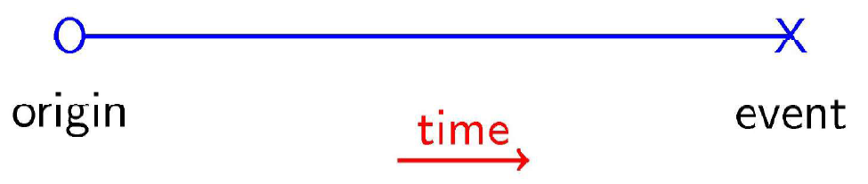

Censoring

- We typically not follow all trial subjects until their outcome occur. Some patients are alive at the end of study or drop out. Sometimes the events may never occur, e.g., cancer, if patients experiences remission.
  - We may still obtain **partial information – right censoring**: “the event had not occurred by time C”
- Another type of censoring is **interval censoring**: all we observe is the interval during which the event occurred, we dunno the exact date (see more in part D)

Right censoring

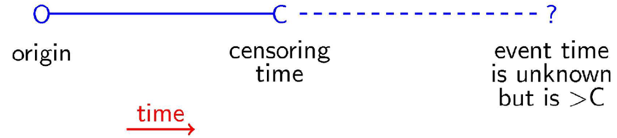

Interval censoring

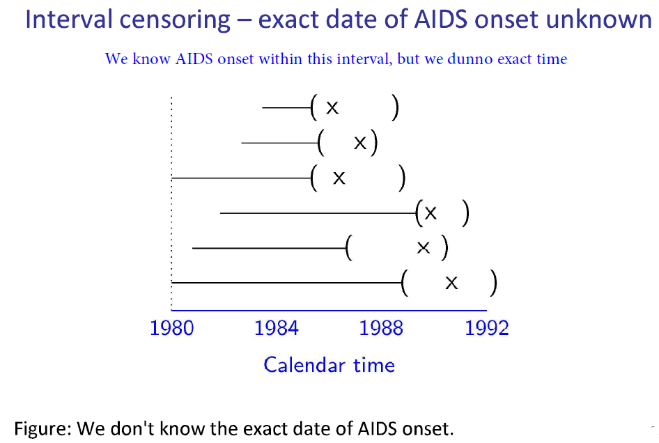

## A. KM estimate & log rank test

### Survival or hazard functions

- **Cumulative density function of event occurs** = *probability that event occur at or before time t*
  - Example: for a probability density function, Pr(T=1) = Pr(T=2) = 0.5
  - F(0.99) = P(T≤0.99) = 0
  - F(1.01) = P(T≤1.01) = P(T=1) = 0.5; F(1.99) = F(T≤1.99) = P(T=1) =0.5
  - F(2.01) = P(T≤2.01) = P(T=1) + P(T=2) = 1
- **Survival function** = *probability of surviving event-free beyond time t*
  - Probability takes value between 0 and 1, so S(t) takes value between 0 and 1

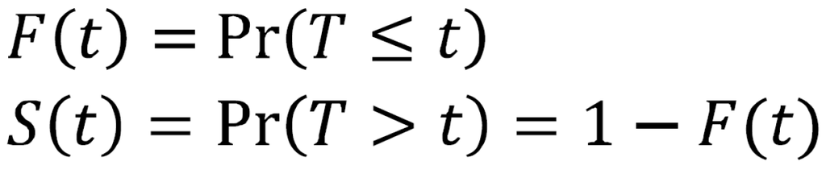

- **Hazard function** = *rate at which the event occurs at time t* conditional on it not having yet occurred = If I haven’t encountered an event, what is the probability that I will encounter the event in a second?

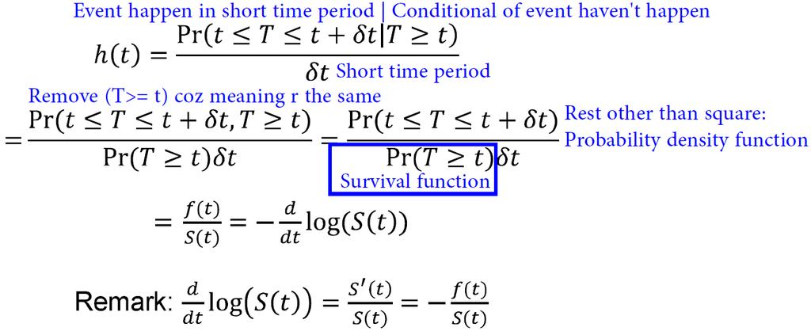

### KM estimator & log rank test (R)

- Survival function can be estimated with the Kaplan-Meier(KM) estimator
  - Account for right-censoring
  - A plot of KM estimate is **a series of horizontal steps of declining magnitude which approximate the true survival function (an underlying curve)**

In package `survival`

- `Surv(time, time2, event, type)` …survival object
  - **time**…follow-up time (for right-censored data) or starting time (for interval censored data)
  - **time2**…not used (right-censored data) or ending time (interval censored data)
  - **event**…defines the outcome: 1 = event occurred at time; 0 = right censored (right censored data); 2 = left censored; 3 = interval censored (interval censored data)
  - **type**…types of censoring, e.g., “right”, “left”, “interval”
- `survfit()`…obtain **KM estimates using the survival object** as dependent variable
- `survdiff()`…test whether KM curves for 2 groups are **significantly different**

```r
# A histochemical marker (HPA) discriminates between tumours that have metastasized and
# those that have not. But can it predict survival?
hpa <- read.csv("Data/examplehpa.csv")
library(survival)
```

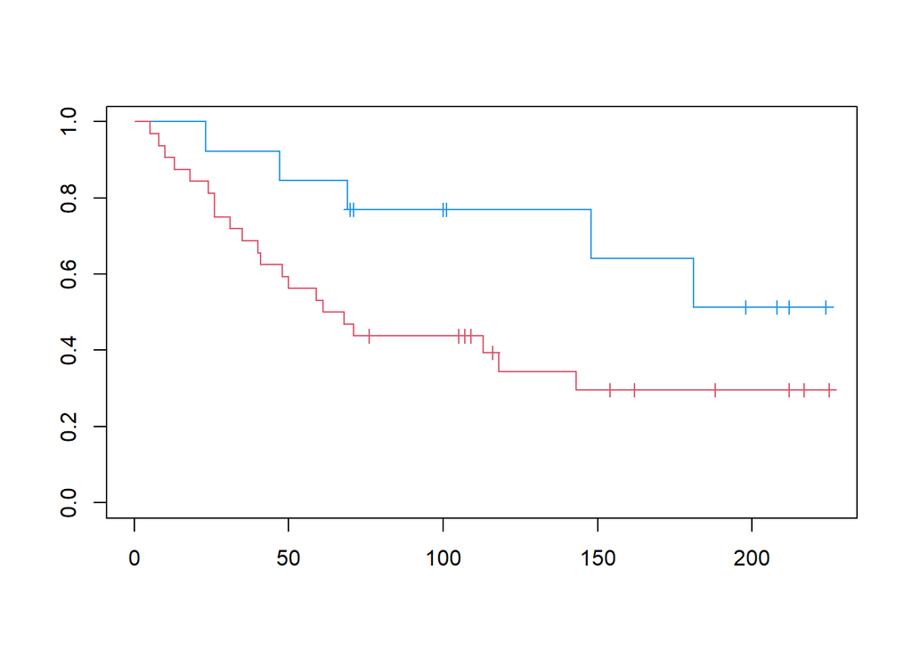

```r
## KM estimates for 2 groups
hpa.km2 <- survfit(Surv(time, event, type="right")~staining, data=hpa)# Staining indicates fitting 2 KM curve
plot(hpa.km2, conf.int=F, mark.time=T, col=c(4,2)) # Patients with positive staining had worse prognosis
```

```r
## Compare KM estimates for 2 groups -- log rank test
survdiff(Surv(time, event, type="right")~staining, hpa)
# For the HPA data the p-value is 0.06, so the survival functions are not significantly
# different between the two groups
```

```
## Call:
## survdiff(formula = Surv(time, event, type = "right") ~ staining,
##     data = hpa)
##
##             N Observed Expected (O-E)^2/E (O-E)^2/V
## staining=0 13        5     9.57      2.18      3.51
## staining=1 32       21    16.43      1.27      3.51
##
##  Chisq= 3.5  on 1 degrees of freedom, p= 0.06
```

## B. Cox/Proportional hazards (PH) model – semi-parametric with censoring

### Cox/PH model

- Log rank test tell us whether the difference are significant, but can’t tell us the effect size => need cox regression model
- Regression model for survival data
  - Each explanatory variable has a proportional effect on the hazard of death, compared to the hazard in the reference group
- **Assumption: The absolute risk (hazard) may change over time, but the proportional difference between groups should stay the same. Note: No assumption on baseline hazard**
  - General form: $h_i(t) = \exp (\beta x_i)h_0(t)$
  - $h_1(t) = \exp (\beta_1)h_0(t)$ for group 1 vs group 0, where $\exp(\beta_1)$ is the hazard ratio (interpretation similar to risk ratio)
  - Need at least **10** observed events per factor in a multivariable model (right-censored events don’t count)

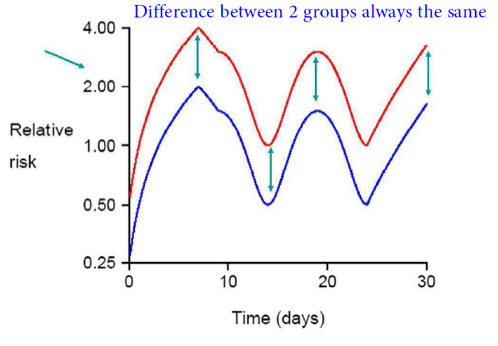

### Model fitting & checking assumptions (R)

Model fitting

`coxph(Surv....)` to fit a cox regression model

```r
## Model fitting
hpa.cox <- coxph(Surv(time, event)~staining, data=hpa)
hpa.cox #see exp(coef)
summary(hpa.cox) #give u 95%CI
# Positive HPA staining insignificantly associated with increased risk of death (HR 2.48; 95%CI: 0.93 to 6.63; p-value: 0.07)
```

```
## Call:
## coxph(formula = Surv(time, event) ~ staining, data = hpa)
##
##            coef exp(coef) se(coef)     z      p
## staining 0.9093    2.4827   0.5009 1.815 0.0695
##
## Likelihood ratio test=3.88  on 1 df, p=0.04874
## n= 45, number of events= 26
## Call:
## coxph(formula = Surv(time, event) ~ staining, data = hpa)
##
##   n= 45, number of events= 26
##
##            coef exp(coef) se(coef)     z Pr(>|z|)
## staining 0.9093    2.4827   0.5009 1.815   0.0695 .
## ---
## Signif. codes:  0 '***' 0.001 '**' 0.01 '*' 0.05 '.' 0.1 ' ' 1
##
##          exp(coef) exp(-coef) lower .95 upper .95
## staining     2.483     0.4028    0.9302     6.626
##
## Concordance= 0.603  (se = 0.042 )
## Likelihood ratio test= 3.88  on 1 df,   p=0.05
## Wald test            = 3.3  on 1 df,   p=0.07
## Score (logrank) test = 3.52  on 1 df,   p=0.06
```

3 tests to check assumptions

1. Complementary log-log scaled KM plot
   - Look for parallel lines between groups (if PH assumptions holds, we expect a vertical shift when plotting log(-log S(t)) against t or log t)

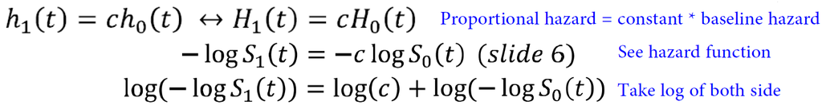

2. Check with time dependent covariate
   - If it is significant, the relative hazard isn’t constant through time.
   - `cox.zph()`creates interaction with time based on Schoendelf residuals, see if it’s significant
     - Specific to each covariate
     - Based on partial likelihood
3. Residual plot (plot Schoenfield residuals over time)

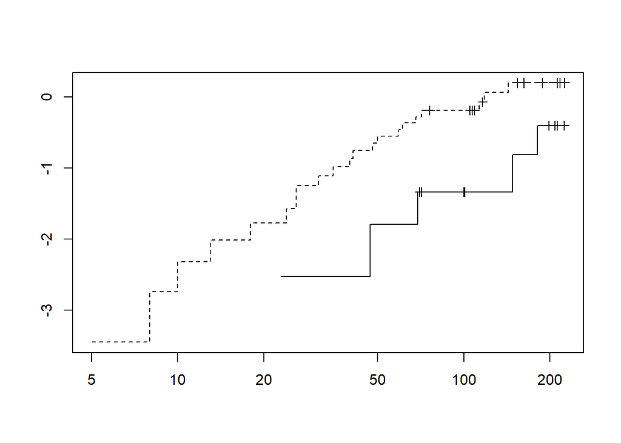

```r
## Assumption test 1
#Note: hpa.km2 <- survfit(Surv(time, event, type="right")~staining, data=hpa)
plot(hpa.km2, fun="cloglog", lty=1:2, mark.time=T) #fun="cloglog" means loglog plot
```

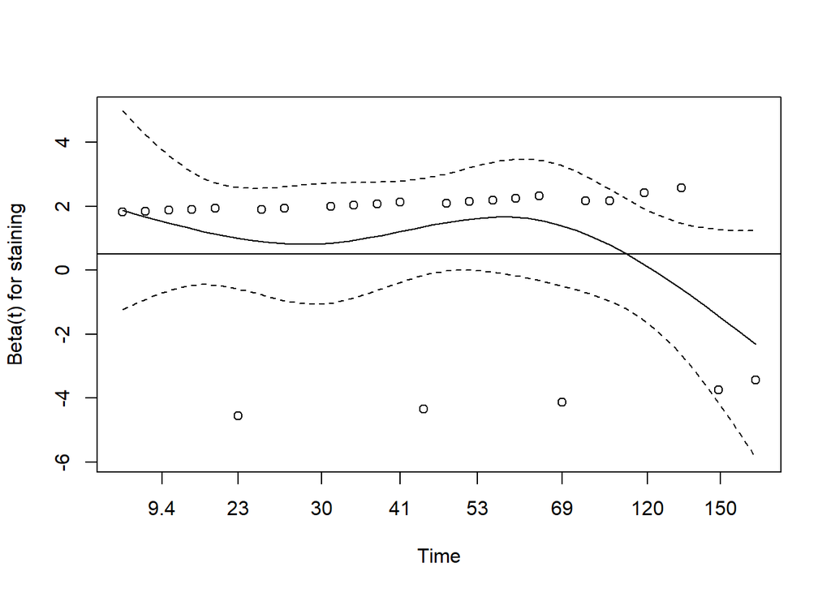

```r
# Looks more or less parallel except near the end

## Assumption test 2
hpa.cox.zph <- cox.zph(hpa.cox)
hpa.cox.zph
# No significant interaction with time (p>0.05)

## Assumption test 3
plot(hpa.cox.zph)
abline(h=0.5)
```

```r
# No obvious pattern over time.
# Wt taught in lecture: Even we allow beta change with time, we can still draw a horizontal
# line within CI => cannot reject null hypothesis that beta is a constant over time.
# Proportional hazard assumption is not invalid
```

```
##          chisq df    p
## staining  1.32  1 0.25
## GLOBAL    1.32  1 0.25
```

### Assumption fails

- If PH assumption fails
  - Perform a stratified analysis => maybe when focusing in a subgroup (male/female), the assumption still holds
  - Include interactions with time => adjust for time variant by adding an interaction term with time. Make the PH assumption invalid.
  - Include time-varying covariates => The fact that theta(t) changing over time may be explained by time-dependent variables

## C. Accelerated failure time (AFT) model – parametric without censoring

### AFT model

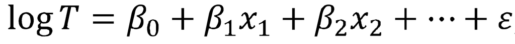

where T is the survival time, and ε follows some error distribution

### Example (R)

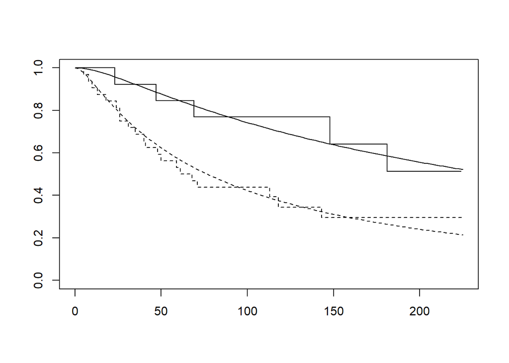

```
## Call:
## survreg(formula = Surv(time, event) ~ staining, data = hpa, dist = "lognormal")
##
## Coefficients:
## (Intercept)    staining
##    5.491726   -1.151172
##
## Scale= 1.359451
##
## Loglik(model)= -154.5   Loglik(intercept only)= -157
##  Chisq= 4.96 on 1 degrees of freedom, p= 0.0259
## n= 45
##  staining
## 0.3162659
##                  2.5 %      97.5 %
## (Intercept) 96.9583761 607.3895272
## staining     0.1141304   0.8764017
```

```r
## Fitting model
hpa.aft1 <- survreg(Surv(time, event)~staining, data=hpa, dist="lognormal")
hpa.aft1
# Assume log normal distribution => have intercept
# 5.49 when staining = 0 (ref group/hpa-ve); 5.49-1.15 when staining = 1
exp(coef(hpa.aft1)[2]) #AF = 0.3162659
exp(confint(hpa.aft1)) #CI = 0.1141304, 0.8764017
# Positive HPA staining associated with faster death (AF 0.32; 95%CI: 0.11 to 0.88)
# Wt taught in lecture: +ve HPA is 0.32 when -ve HPA is 1. <1 means smaller median time to event.

## Plot the model (compare KM estimator with AFT model) Note: 1-plnorm to get survival function
plot(hpa.km2, lty=1:2) #KM esetimator
curve(1-plnorm(x, meanlog=hpa.aft1$coef[1], sdlog=hpa.aft1$scale), add=T, lty=1) #AFT model -ve(ref) group
curve(1-plnorm(x, meanlog=hpa.aft1$coef[1]+hpa.aft1$coef[2], sdlog=hpa.aft1$scale), add=T, lty=2) #AFT model +ve group
```

### Model comparison and checking

- Model comparison
  - **Compare AICs or log-likelihoods** of alternative parametric methods
  - (can use AICs coz AFT is parametric model)
- Model checking
  - **Plot fitted curves against KM estimates**
  - (we can plot fit many AFT models, need to check whether it is consistent with non-parametric KM estimate)

### PH vs AFT model

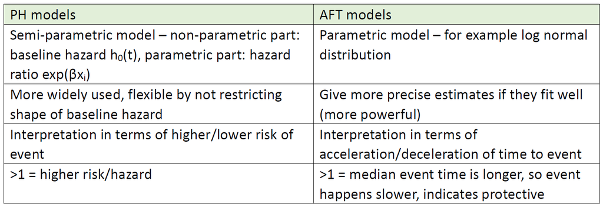

## D. Censoring and truncation – parametric with censoring

### Censoring vs Truncation

- Censoring: we knew about the individuals with HIV but **without AIDs at the analysis date** (we knew there are some long incubation periods, but we didn’t know exactly how long they were)
- Truncation: we **never knew about the individuals not yet suffering from AIDs** (they didn’t appear in our dataset)

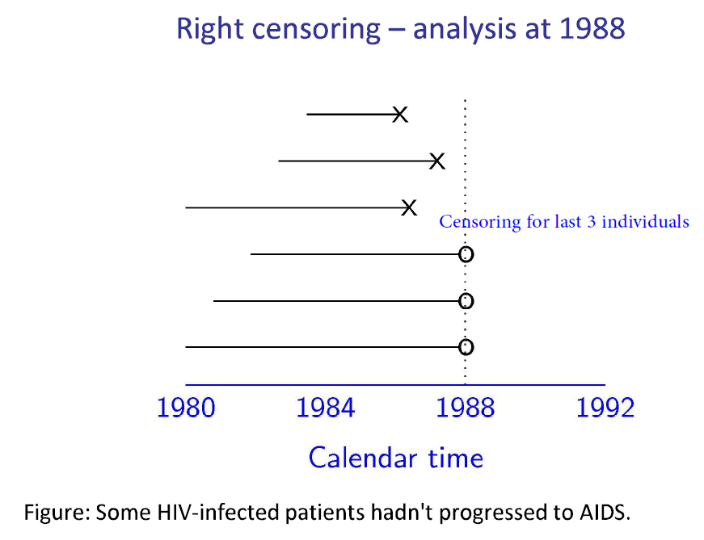

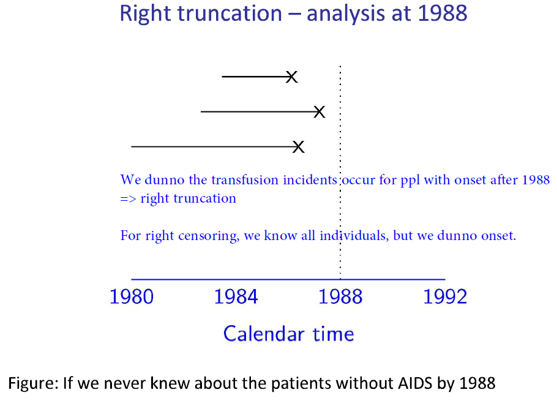

### Analysis of censored data

For parametric inference **(with right censoring)**, the likelihood is $l(\theta) = \prod_{i=1}^{n}f(t_i|\theta)^{\delta_i}(1-F(t_i|\theta))^{1-\delta_i}$ where

- $f()$ is the pdf for non-censored individuals (know exact event time) (**non-censored**)
- $1 - F()$ is 1-cdf hence is survival function (dunno exact event time) (**censored**)
  - $\delta_i$ is the event indicator (= 1 for uncensored, =0 for censored)
  - (Likelihood function is multiplying uncensored and censored event tgt coz assuming the events are independent)

For **other types of censoring or truncation**,

1. Consider the value of the likelihood from each individual observation $i = 1...n$
   1. For exactly-observed times $t_i$, the value was $f(t_i)$
   2. (**censored**)For right-censored times $c_i$, the value is ${1-F(t_i)}$
   3. (**censored**)For times censored on the interval $(L_i, R_i)$, the value is given by ${F(R_i)-F(L_i)}$
   4. (**truncated**)For times $t_i$ with right-truncation at $T$, the value is given by $f(t_i)/F(T)$ where $F(T)$ is the truncated time
      - Note that we won’t get the same answer if we simply take the midpoint of any censoring intervals.
      - R command `survreg` can handle interval censored data  
        syntax like: `survreg(Surv(timeL, timeR, event=3, type="interval")~1)` This is a no covariant (intercept only) model

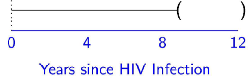

2. Fitting parametric models
   - To fit parametric (e.g. lognormal) distributions to censored or truncated data, simply multiply together the values from each observation
   - Then maximize the likelihood to estimate the distribution

## E.Review

- Survival analysis handled data with right cenosirng, right truncation or interval censoring
- Cox regression model allow flexible analysis without specifying the baseline hazard
- Accelerated time failure model is a parametric method as an alternative way to analyze survival data

# Part 2 Multiple imputation

## A. Recap on missing data

### Survivorship bias

[figure not shown]

### Missing data

- Potential reasons for missing data: dropout, incomplete response, censored
- Types of missing data
  1. **Missing completely at random (MCAR)** – missingness independent of all variables  
     e.g. Accidental loss of data
  2. **Missing at random (MAR)** – missingness dependent on observed variables  
     e.g. Loss of contact of recovered patients
  3. **Missing not at random (MNAR)** – missingness dependent on unobserved variables  
     e.g. Patients with high BMI less likely to respond to treatment, but the study did not record the BMI
- Methods to handle missing data
  - Valid for MCAR
    1. Complete case analysis…Only analyze cases with **complete data**
       - May lose substantial information
    2. Nearest neighbour imputation…Impute missing value from **most similar subject**
    3. Mean imputation…Impute missing values by the **mean** of the variable
       - Reduces variation in the data
       - May not maintain associations between variables
  - Valid for MAR
    1. Regression imputation…Predict missing value from **regression models** (linear regression or other GLM)
    2. Multiple imputation …Single imputation treats imputed values as actual responses => Multiple imputation accounts for variability / uncertainty in the imputed data
    3. Inverse probability weighting…Estimate the **probability of response** based on some external knowledge
       - Weight the observed data using the inverse probability

### Example for traditional method (MCAR or MAR)

```r
## Create a dataset with missing data
mvc <- read.csv("Data/mvc.csv")
mvc.miss <- mvc
mvc.miss$age[1:10] <- NA
```

```r
## Complete case analysis
lm.miss <- lm(MVC~age+height, data=mvc.miss)
summary(lm.miss)

## Mean imputation
mvc.miss$age[1:10] <- mean(mvc.miss$age, na.rm=T) #"na.rm=T" ignore the missing value and calculate the mean, use the mean to replace missing value

## Regression
mvc.miss$age[1:10] <- NA
lm.impute <- lm(age~height, data=mvc.miss)
mvc.miss$age[1:10] <- predict(lm.impute, mvc.miss)[1:10]
```

```
##
## Call:
## lm(formula = MVC ~ age + height, data = mvc.miss)
##
## Residuals:
##      Min       1Q   Median       3Q      Max
## -225.724  -39.264    3.922   37.907  162.581
##
## Coefficients:
##             Estimate Std. Error t value Pr(>|t|)
## (Intercept) -466.576    441.785  -1.056  0.29994
## age           -6.197      1.755  -3.532  0.00145 **
## height         6.386      2.352   2.716  0.01120 *
## ---
## Signif. codes:  0 '***' 0.001 '**' 0.01 '*' 0.05 '.' 0.1 ' ' 1
##
## Residual standard error: 80.57 on 28 degrees of freedom
##   (10 observations deleted due to missingness)
## Multiple R-squared:  0.5425, Adjusted R-squared:  0.5098
## F-statistic:  16.6 on 2 and 28 DF,  p-value: 1.761e-05
```

## B. Multiple imputation

### Description

- Impute missing variables m times to have m imputed datasets => Obtain estimates from each datasets => Combine the m estimates to obtain overall estimates
- Practically, m=10, 20 or 50 is sufficient

### Construct datasets (R)

Package: `Hmisc` to construct imputed datasets

- `transcan(formula, n.impute, shrink, data, imputed)` or `aregImpute`
  - **formula**…for imputation (not model fitting), should be like ~y+x_1_+x_2_
  - **n.impute**…number of imputations
  - **shrink = T**…to avoid overfitting for imputation
  - **data**…data frame
  - **imputed = T**…to save the imputed values

```r
## Construct dataset with missing data
mvc.miss <- mvc
mvc.miss$age[1:5] <- mvc.miss$height[6:10] <- NA
```

```r
## Multiple imputation (transcan)
library("Hmisc")
mvc.impute <- transcan(~MVC+age+height, n.impute=50,shrink=T,data=mvc.miss, imputed=T) #use all 3 variables to impute missing data
```

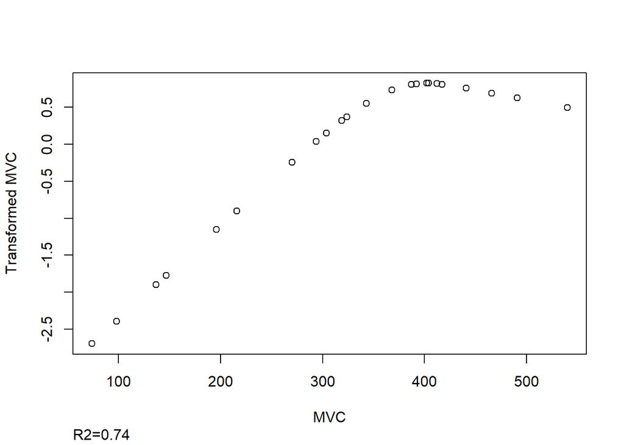

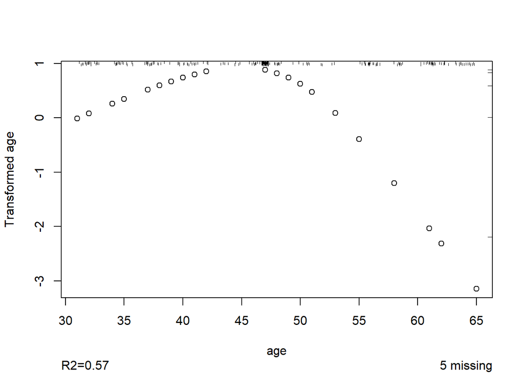

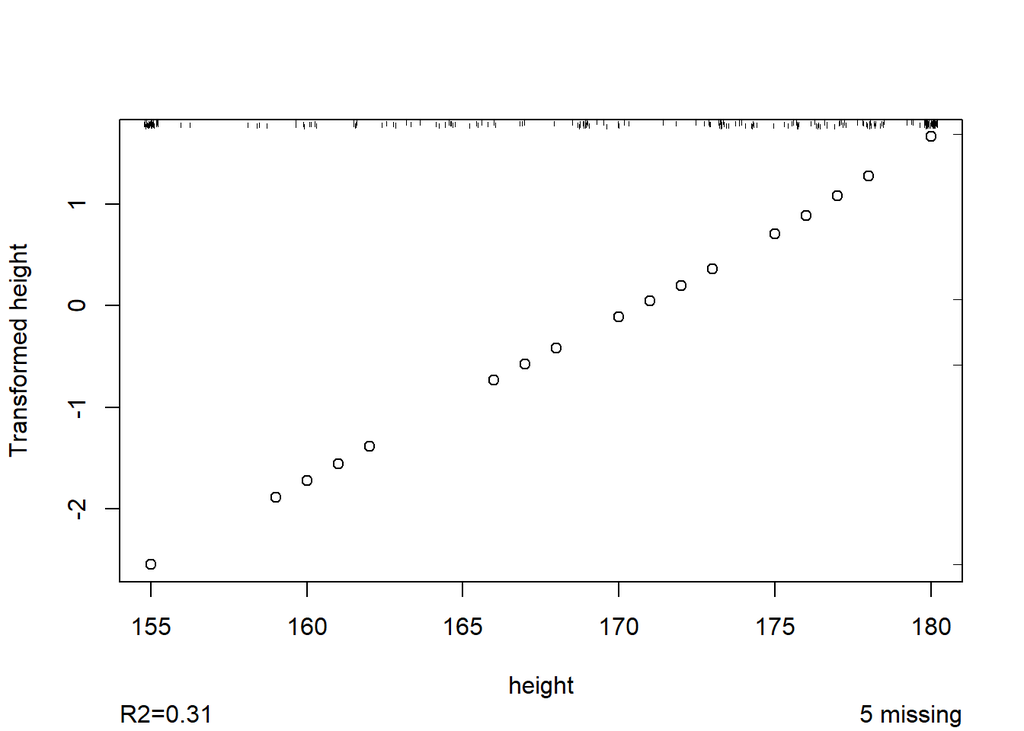

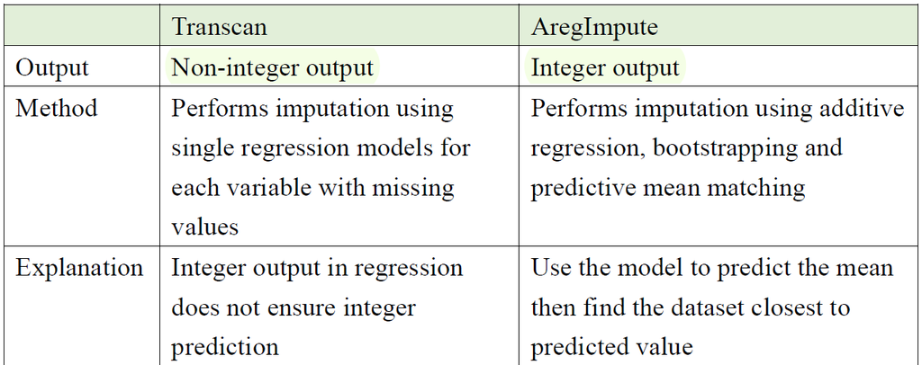

```r
mvc.impute$imputed$age #5 rows coz missing 5 age value; 50 columne coz imputed 50 times
#mvc.impute$imputed to see all imputed missing data (both age and height)

## Multiple imputation (aregImpute)
mvc.impute.areg <- aregImpute(~MVC+age+height,n.impute=50, data=mvc.miss)
mvc.impute$imputed$age #Results interpretation same as transcan except results are integer.
```

### Combine estimates (R)

After constructing imputed datasets, combine estimate

- The final multiple imputation **estimate *Q*** from *m* imputation is given by
  - $\overline{Q} = \frac{1}{m}\sum^{m}_{i=1}\hat{Q}^{(i)}$
- whereas **variance** is
  - $T = \overline{U} + (1+\frac{1}{m})B$ where $B$ and $\overline{U}$ are between- and within- imputation

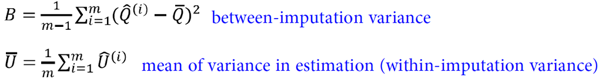

Package: `Hmisc` to refit the model based on the imputed datasets and obtain overall estimates

- `fit.mult.impute(formula, fitter, transcan, data)` or `aregImpute`
  - **formula**…should be like y~x_1_+x_2_
  - **fitter**…the model to fit the data, e.g., lm, glm (for glm, the family option can be included)
  - **transcan**…class object created
  - **data**…data frame

```r
## Multiple imputation (transcan)
mvc.lm.impute <- fit.mult.impute(MVC~age+height, lm, mvc.impute, data=mvc.miss)
summary(mvc.lm.impute) #can see the new estimates now

## Multiple imputation (aregImpute)
mvc.lm.impute.areg <- fit.mult.impute(MVC~age+height, lm, mvc.impute.areg, data=mvc.miss)
summary(mvc.lm.impute.areg)
```

```
##
## Wald Statistic Information
##
## Variance Inflation Factors Due to Imputation:
##
## (Intercept)         age      height
##        1.03        1.06        1.03
##
## Fraction of Missing Information:
##
## (Intercept)         age      height
##        0.03        0.05        0.03
##
## d.f. for t-distribution for Tests of Single Coefficients:
##
## (Intercept)         age      height
##    72601.42    17772.08    47974.72
##
## The following fit components were averaged over the 50 model fits:
##
##   fitted.values
##
##
## Call:
## fit.mult.impute(formula = MVC ~ age + height, fitter = lm, xtrans = mvc.impute,
##     data = mvc.miss)
##
## Residuals:
##      Min       1Q   Median       3Q      Max
## -192.127  -52.229    7.621   26.084  182.709
##
## Coefficients:
##             Estimate Std. Error t value Pr(>|t|)
## (Intercept) -759.364    400.081  -1.898  0.06531 .
## age           -4.050      1.415  -2.863  0.00679 **
## height         7.435      2.194   3.389  0.00165 **
## ---
## Signif. codes:  0 '***' 0.001 '**' 0.01 '*' 0.05 '.' 0.1 ' ' 1
##
## Residual standard error: 88.06 on 38 degrees of freedom
```

[output cut: 30 more lines]

```
## Residuals:
##      Min       1Q   Median       3Q      Max
## -237.132  -36.723    6.659   58.621  176.232
##
## Coefficients:
##             Estimate Std. Error t value Pr(>|t|)
## (Intercept) -656.132    455.979  -1.439   0.1584
## age           -3.988      1.604  -2.487   0.0174 *
## height         6.808      2.553   2.667   0.0112 *
## ---
## Signif. codes:  0 '***' 0.001 '**' 0.01 '*' 0.05 '.' 0.1 ' ' 1
##
## Residual standard error: 98.59 on 38 degrees of freedom
## Multiple R-squared:  0.3111, Adjusted R-squared:  0.2748
## F-statistic: 8.579 on 2 and 38 DF,  p-value: 0.0008423
```

# Part 3 Practical

Explore time to cessation of symptoms in subjects with confirmed influenza virus infection  
A study was conducted in 2007 to investigate household transmission of influenza virus (Cowling et al., 2008, PLoS ONE). An extract of the data regarding duration of illness in index cases may be loaded via

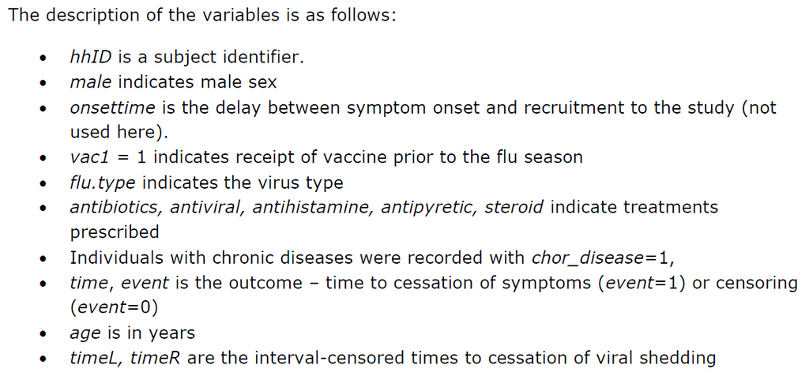

```r
flu <- read.csv("Data/pilot2007.csv")
```

## a) KM estimate

1. Plot the K-M estimate of the time to cessation of symptoms

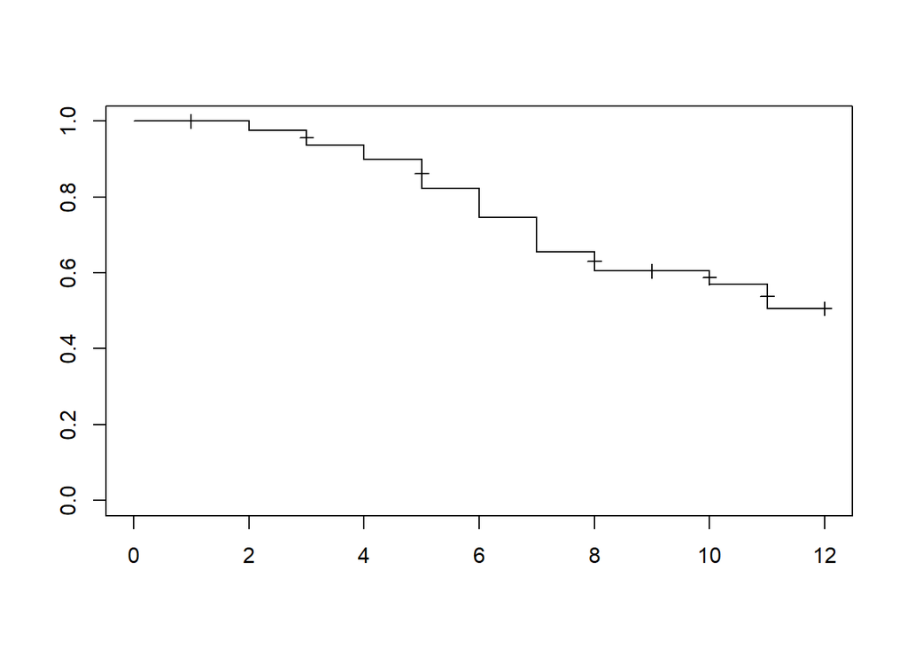

```r
plot(survfit(Surv(time,event)~1, data=flu), conf.int=F, mark.time=T)
```

```r
#mark.time=T indicates time of censoring
```

## b) KM estimate grouping by “cut”

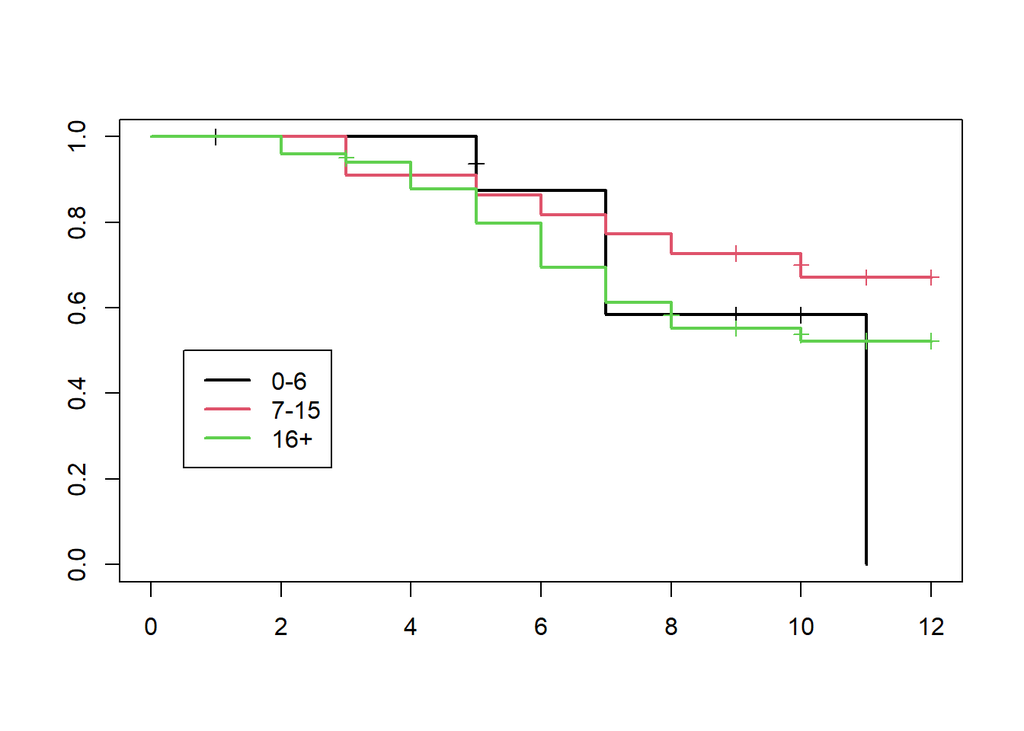

```r
plot(survfit(Surv(time, event)~cut(age, breaks=c(0,6,16,100)), data=flu), mark.time=T, col=1:3, lwd=2)
legend(0.5, 0.5, c("0-6", "7-15", "16+"), col = 1:3, lwd=2)
```

## c) KM estimate grouping by given groups

3. Plot the K-M estimate by flu type.

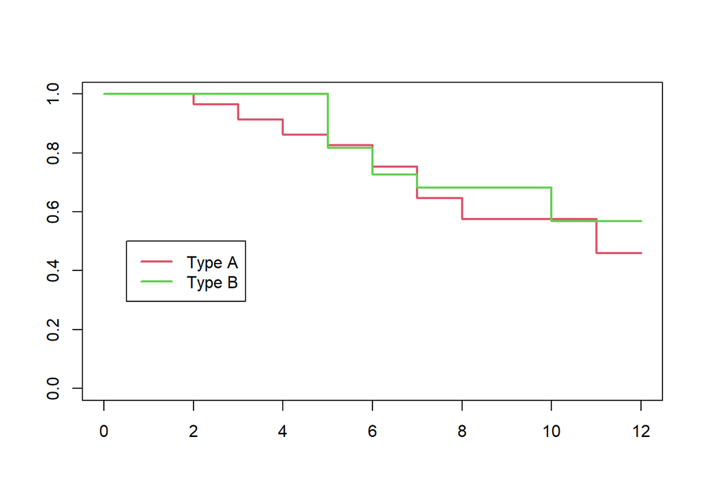

```r
plot(survfit(Surv(time, event)~flu.type, data=flu), col=2:3, lwd=2)
legend(0.5, 0.5, c("Type A", "Type B"), col = 2:3, lwd=2)
```